# XGBoost bayes opt with tidymodels

Fellipe Gomes

30 Maio, 2020

If you like the post don’t forget the upvote!

# 1 Problem definition

The data presented in this challenge are widely used in data science education and illustrate a problem of regression. The variable we want to estimate is numeric.

More information about data: http://jse.amstat.org/v19n3/decock.pdf

[figure not shown]

Source: <gomesfellipe.github.io> (my blog)

The solution for this competition will be based on an old post on my blog about tree-based machine learning models.

See the post at: https://gomesfellipe.github.io/post/2018-08-31-modelos-em-arvore/modelos-em-arvore/

# 2 Data Science framework

Let’s follow a well-known framework in data science by R users:

Dependencies:

```r
library(visdat)
library(tidyverse)
library(tidymodels)
library(patchwork)

theme_set(theme_bw())

ncores <- 4
```

# 3 Import data

Loading train and test data:

```r
train_data <- read_csv("train.csv")
test_data <- read_csv("test.csv")
```

# 4 Tidy

Before modeling, let’s check out some information about the data structure:

## 4.1 Data Structure

Take a look at the data structure:

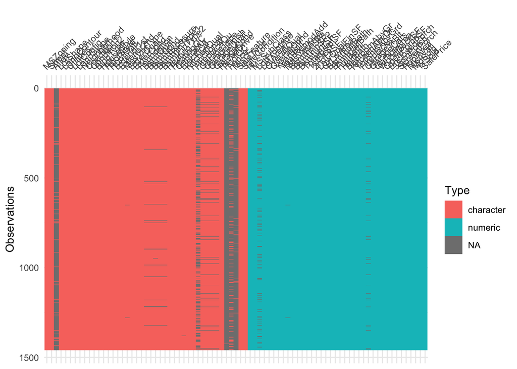

```r
vis_dat(train_data)
```

There are columns with many missing values

## 4.2 Percentages:

Percentage of data types

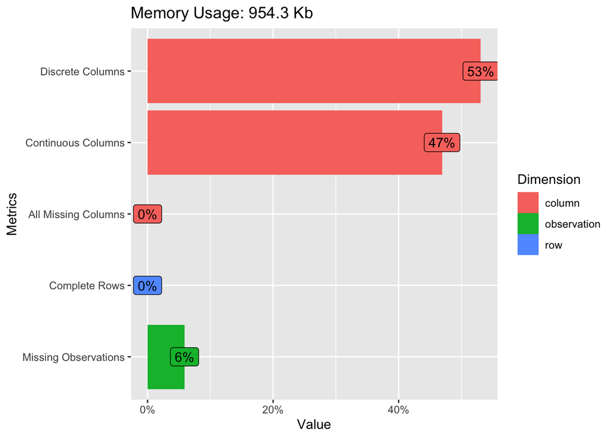

```r
DataExplorer::plot_intro(train_data)
```

Most of the data is discrete

## 4.3 Missing data

Take a look at the columns that have missing data:

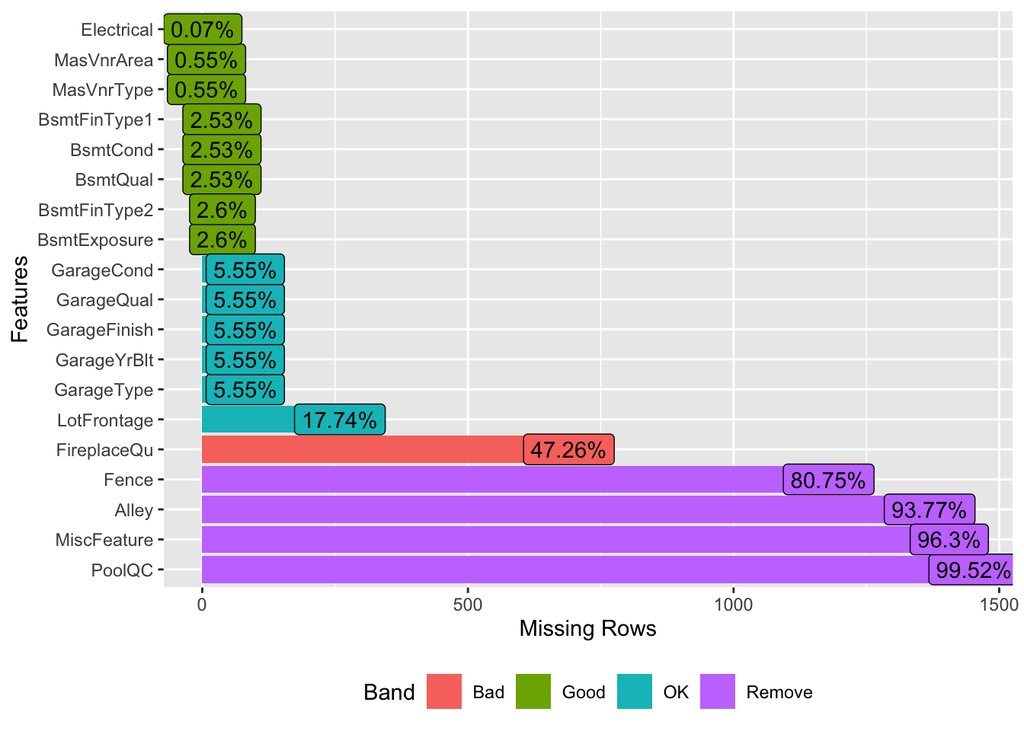

```r
p <- DataExplorer::plot_missing(train_data, missing_only = T)
```

```r
cols_to_remove <- p$data %>% filter(Band %in% c("Remove", "Bad")) %>% pull(feature)
```

Columns to remove: Alley, FireplaceQu, PoolQC, Fence, MiscFeature

## 4.4 Target

The target variable in this problem is numeric. Let’s see what the behavior of your distribution is

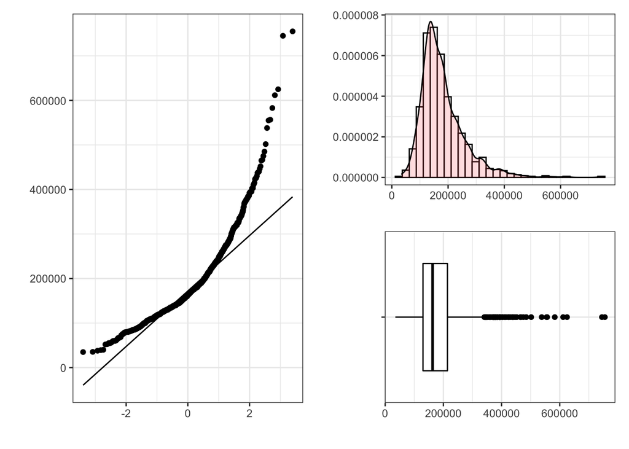

```r
# hist
g1 <- ggplot(train_data, aes(x=SalePrice)) +
 geom_histogram(aes(y=..density..), colour="black", fill="white")+
 geom_density(alpha=.2, fill="#FF6666")+
  labs(x = "", y = "")

# boxplot
g2 <- ggplot(train_data, aes(y=SalePrice)) +
 geom_boxplot(aes(x=""), colour="black", fill="white")+
  coord_flip()+
  labs(x = "", y = "")

# qqplot
g3 <- ggplot(train_data, aes(sample = SalePrice))+
  stat_qq()+
  stat_qq_line()+
  labs(x = "", y = "")

g3 | g1 / g2
```

What if we apply the log transformation?

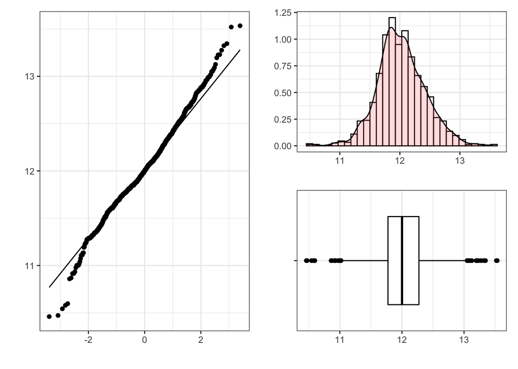

```r
train_data <- train_data %>% mutate(SalePrice = log(SalePrice))

# hist
g1 <- ggplot(train_data, aes(x=SalePrice)) +
 geom_histogram(aes(y=..density..), colour="black", fill="white")+
 geom_density(alpha=.2, fill="#FF6666")+
  labs(x = "", y = "")

# boxplot
g2 <- ggplot(train_data, aes(y=SalePrice)) +
 geom_boxplot(aes(x=""), colour="black", fill="white")+
  coord_flip()+
  labs(x = "", y = "")

# qqplot
g3 <- ggplot(train_data, aes(sample = SalePrice))+
  stat_qq()+
  stat_qq_line()+
  labs(x = "", y = "")

g3 | g1 / g2
```

# 5 Transform

We arrived at the moment of analysis when we need to apply transformations to the data so that they reflect the study in a more realistic way

The same pre-processing applied to the training data needs to be applied to the test data. For this task we will use the `recipes` package of the `tidymodels` framework to prepare a transformation recipe.

```r
SalePrice_recipe <- recipe(train_data, SalePrice ~ .) %>%
  step_rm(Id, Street, Utilities) %>%
  step_rm(one_of(cols_to_remove)) %>%
  step_log(all_numeric(),-all_outcomes(), offset = 1) %>%
  step_normalize(all_numeric(),-all_outcomes()) %>%
  step_other(all_nominal(), -all_outcomes(), threshold = 0.01) %>%
  step_novel(all_predictors(), -all_numeric()) %>%
  step_knnimpute(all_predictors()) %>%
  step_dummy(all_nominal(), -all_outcomes())

# prep(SalePrice_recipe)
# juice(prep(SalePrice_recipe))
# SalePrice_bake <- bake(prep(SalePrice_recipe), new_data = test_data)
```

# 6 Model / Visualise

Define model:

```r
SalePrice_xgb_model <-
  boost_tree(
  trees = tune(), learn_rate = tune(),
  tree_depth = tune(), min_n = tune(),
  loss_reduction = tune(),
  sample_size = tune(), mtry = tune(),
  ) %>%
  set_mode("regression") %>%
  set_engine("xgboost", nthread = ncores)
```

Define workflow:

```r
SalePrice_workflow <- workflow() %>% add_recipe(SalePrice_recipe)

SalePrice_xgb_workflow <-SalePrice_workflow %>% add_model(SalePrice_xgb_model)
```

Define params:

```r
xgboost_params <- parameters(
  trees(), learn_rate(),
  tree_depth(), min_n(),
  loss_reduction(),
  sample_size = sample_prop(), finalize(mtry(), train_data)
)

xgboost_params <- xgboost_params %>% update(trees = trees(c(100, 500)))
```

Define folds to cross validation:

```r
set.seed(123)
SalePrice_vfold <- vfold_cv(train_data, v = 5, strata = SalePrice)
```

Increment workflow:

```r
workflow_SalePrice_xgb_model <-
  workflow() %>%
  add_model(SalePrice_xgb_model) %>%
  add_recipe(SalePrice_recipe)
```

Iterative Bayesian optimization:

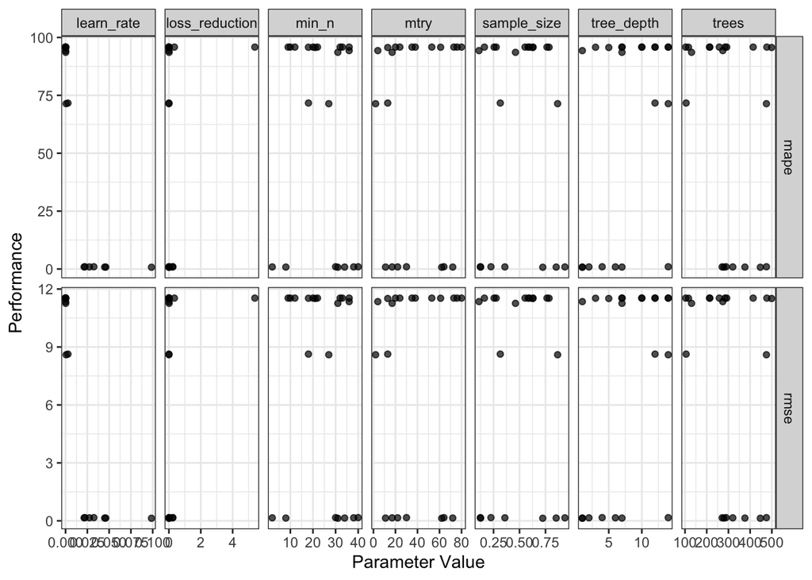

```r
# doParallel::registerDoParallel(ncores)

set.seed(321)
xgboost_tune <-
  workflow_SalePrice_xgb_model %>%
  tune_bayes(
    resamples = SalePrice_vfold,
    param_info = xgboost_params,
    # initial = ?,
    iter = 30,
    metrics = metric_set(rmse, mape),
    control = control_bayes(no_improve = 10,
                            save_pred = T, verbose = F)
  )

# doParallel::stopImplicitCluster()
autoplot(xgboost_tune)
```

Check results:

```r
SalePrice_best_model <- select_best(xgboost_tune, "rmse", maximize = F)
print(SalePrice_best_model)
```

```
FALSE # A tibble: 1 x 7
FALSE    mtry trees min_n tree_depth learn_rate loss_reduction sample_size
FALSE   <int> <int> <int>      <int>      <dbl>          <dbl>       <dbl>
FALSE 1    62   447    31          1     0.0986        0.00603       0.724
```

Finalize model:

```r
SalePrice_final_model <- finalize_model(SalePrice_xgb_model, SalePrice_best_model)
SalePrice_workflow    <- workflow_SalePrice_xgb_model %>% update_model(SalePrice_final_model)
SalePrice_xgb_fit     <- fit(SalePrice_workflow, data = train_data)
```

Evalue model:

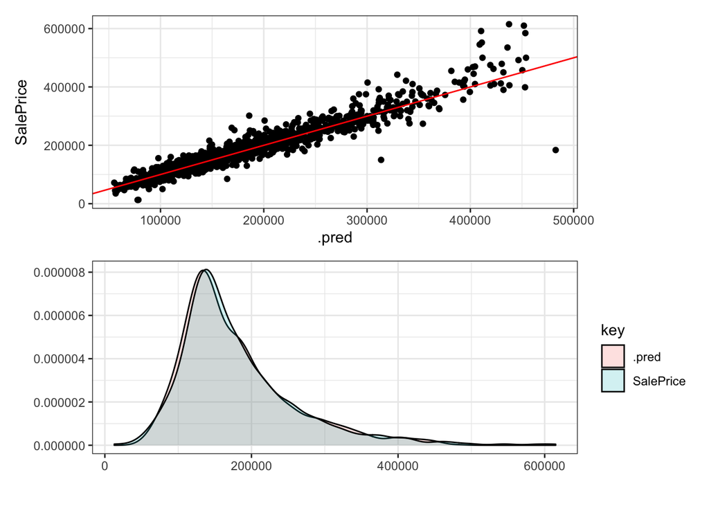

```r
pred <-
  predict(SalePrice_xgb_fit, test_data) %>%
  mutate(modelo = "XGBoost",
         .pred = exp(.pred)) %>%
  bind_cols(read_csv("full-score.csv") %>% select(SalePrice))

g1 <-
  pred %>%
  ggplot(aes(x = .pred, y = SalePrice))+
  geom_point()+
  geom_abline(intercept = 0, col = "red")


g2 <-
  pred %>%
  select(.pred, SalePrice) %>%
  gather(key, value) %>%
  ggplot(aes(x=value, volor = key, fill = key)) +
  geom_density(alpha=.2)+
  labs(x = "", y = "")

g1 / g2
```

# 7 Communicate

In this case of a data science project, the communication of our results will be via submission:

```r
read_csv("sample_submission.csv") %>%
  select(-SalePrice) %>%
  bind_cols(pred %>% select(SalePrice)) %>%
  write_csv("submission.csv")
```